# Introduction to Caret

Michael Battaglia

January 30, 2018

## Introduction

`caret` provides a common interface for several algorithms. The syntax is intuitive and it makes many machine learning tasks easier.

- Easy to set up cross-validation
- Automated pre-processing for each cv-split
  - Prevents data snooping
- Try several model types with minimal code changes
- Functions for calculating performance metrics

## Setup

I’ll continue to use the song dataset, which I also used for the python pedagogy.

```r
songs <- read_csv("YearPredictionMSD.txt", col_names = FALSE)
names(songs) <- c("Year", paste0("X", 1:90))

train <- songs %>%
  sample_n(5000)

test <- songs %>%
  setdiff(train)

X_train <- train %>%
  select(-Year)

y_train <- train %>%
  pull(Year)

X_test <- test %>%
  select(-Year)

y_test <- test %>%
  pull(Year)
```

`caret` by default will tune parameters in parallel, if a parallel backend is registered.

```r
options(mc.cores = 6)

library(doFuture)
registerDoFuture()
plan(multiprocess)
```

## Simple Regression

The `train` function is the highest-level `caret` function. It can handle both simple and complex modeling procedures without much of a change in syntax.

The main parameters:  
`trControl`: output of `trainControl` function, cross-validation specification  
`tuneGrid`: grid of parameters to try (optional)  
`tuneLength`: if using random search, the maximum to try for each parameter  
`preProcess`: applies data pre-processing to each fold appropriately  
- standardizing  
- pca  
- imputation  
`method`: algorithm to use

Here is the most basic example.

```r
lm_fit <- train(X_train, y_train,
                method = "lm")
```

Let’s say we want to standardize our predictors prior to modeling. The `preProcess` argument has a multitude of options for transforming the features.

```r
lm_fit <- train(X_train, y_train,
                preProcess = c("center", "scale"),
                method = "lm")
```

## Lasso

```r
lasso_fit <- train(X_train, y_train,
                preProcess = c("center", "scale"),
                method = "lasso")
```

The lasso has a tuning parameter `s`/`fraction`, but we didn’t specify anything. What did `caret` do?

```r
lasso_fit
```

```
## The lasso
##
## 5000 samples
##   90 predictor
##
## Pre-processing: centered (90), scaled (90)
## Resampling: Bootstrapped (25 reps)
## Summary of sample sizes: 5000, 5000, 5000, 5000, 5000, 5000, ...
## Resampling results across tuning parameters:
##
##   fraction  RMSE       Rsquared   MAE
##   0.1       10.392840  0.1350003  7.663689
##   0.5        9.835220  0.1999867  7.072929
##   0.9        9.865418  0.1986060  7.106585
##
## RMSE was used to select the optimal model using the smallest value.
## The final value used for the model was fraction = 0.5.
```

```r
predict(lasso_fit$finalModel, type = "coefficients",
        s = lasso_fit$bestTune$fraction,
        mode = "fraction")
```

```
## $s
## [1] 0.5
##
## $fraction
##   0
## 0.5
##
## $mode
## [1] "fraction"
##
## $coefficients
##           X1           X2           X3           X4           X5
##  4.146513972 -1.850975625 -1.578347933  0.000000000  0.000000000
##           X6           X7           X8           X9          X10
## -2.328255926  0.000000000 -0.093056677 -0.462017593  0.000000000
##          X11          X12          X13          X14          X15
## -0.291157251 -0.086548786  0.763900569  0.269235240  0.000000000
##          X16          X17          X18          X19          X20
##  1.112223666  0.475997417  0.000000000  0.000000000  0.972071452
##          X21          X22          X23          X24          X25
##  0.000000000  0.000000000  0.450548150  0.000000000 -0.287703022
##          X26          X27          X28          X29          X30
##  0.000000000  0.293112150  0.000000000  0.007626801  0.000000000
##          X31          X32          X33          X34          X35
## -0.212344366  0.000000000  0.000000000  0.000000000  0.000000000
##          X36          X37          X38          X39          X40
## -0.377705044  0.052651246  0.172278231  0.179146622 -0.362031733
##          X41          X42          X43          X44          X45
## -0.184653263  0.000000000 -0.244842905  0.000000000  0.000000000
##          X46          X47          X48          X49          X50
##  0.000000000  0.209217264 -0.414381567  0.000000000  0.000000000
##          X51          X52          X53          X54          X55
##  0.000000000  0.000000000  0.000000000  0.000000000  0.000000000
##          X56          X57          X58          X59          X60
##  0.000000000 -0.584528732  0.185876613 -0.124191242  0.000000000
##          X61          X62          X63          X64          X65
## -0.154757469 -0.177640214 -0.184809236  0.227165629  0.000000000
##          X66          X67          X68          X69          X70
##  0.000000000  0.000000000  0.000000000  0.000000000  0.000000000
##          X71          X72          X73          X74          X75
## -0.214915701  0.000000000  0.000000000  0.000000000  0.119960627
##          X76          X77          X78          X79          X80
##  0.000000000  0.000000000 -0.580434419  0.000000000  0.000000000
##          X81          X82          X83          X84          X85
##  0.000000000  0.000000000  0.192755638  0.217300044  0.152126665
##          X86          X87          X88          X89          X90
##  0.000000000  0.103391266 -0.189687770 -0.065822712 -0.003039494
```

The random search provides us with a starting point. We should further examine values of `s` near `0.5`. To do this we can create our own grid of parameters for `caret` to search over.

The procedure for specifying and parameter-tuning is straightforward.

First we specify the cross-validation procedure using `trainControl`.

```r
fitControl <- trainControl(method = "cv",
                           number = 5,
                           allowParallel = TRUE)
```

We use the `expand.grid` function to specify the parameters to search over.

```r
lasso_grid <- expand.grid(
  fraction = 3:8 * 0.1
)
```

Then pass these objects into the `train` function.

```r
lasso_fit <- train(X_train, y_train,
                preProcess = c("center", "scale"),
                method = "lasso",
                trControl = fitControl,
                tuneGrid = lasso_grid
                )
```

Printing the object provides an excellent summary of results.

```r
lasso_fit
```

```
## The lasso
##
## 5000 samples
##   90 predictor
##
## Pre-processing: centered (90), scaled (90)
## Resampling: Cross-Validated (5 fold)
## Summary of sample sizes: 4000, 4002, 4000, 3999, 3999
## Resampling results across tuning parameters:
##
##   fraction  RMSE       Rsquared   MAE
##   0.3       10.015246  0.1868508  7.240761
##   0.4        9.917034  0.1977932  7.139203
##   0.5        9.851118  0.2056632  7.077084
##   0.6        9.822456  0.2088634  7.053810
##   0.7        9.812950  0.2102025  7.047722
##   0.8        9.821694  0.2092950  7.054486
##
## RMSE was used to select the optimal model using the smallest value.
## The final value used for the model was fraction = 0.7.
```

And plotting the object produces a nice visualization of the grid search. (can use ggplot!)

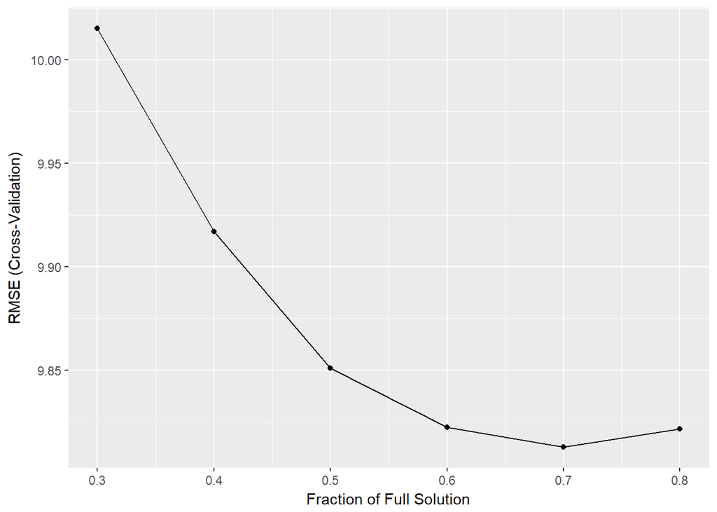

```r
ggplot(lasso_fit)
```

## Random Forest

We will start with a random forest, using `ranger`.

The parameters to tune are `mtry`, `splitrule`, and `min.node.size`.

We will use `expand.grid` to create a grid of model-parameters to try. In this case we only tune `mtry`.

```r
rf_grid <- expand.grid(
    mtry = 5:10*5,
    splitrule = "variance",
    min.node.size = 5
  )
```

Now we use the `train` function to fit our random forest.

```r
rf_fit <- train(X_train, y_train,
                trControl = fitControl,
                tuneGrid = rf_grid,
                preProcess = c("center", "scale"),
                method = "ranger",
                num.trees = 2000,
                num.threads = 1)
```

We can examine the fit output to explore the best combination of parameters.

```r
rf_fit
```

```
## Random Forest
##
## 5000 samples
##   90 predictor
##
## Pre-processing: centered (90), scaled (90)
## Resampling: Cross-Validated (5 fold)
## Summary of sample sizes: 4000, 4001, 4000, 3999, 4000
## Resampling results across tuning parameters:
##
##   mtry  RMSE      Rsquared   MAE
##   25    9.847805  0.2167145  7.205217
##   30    9.852592  0.2136819  7.197324
##   35    9.839665  0.2147813  7.180800
##   40    9.844780  0.2127274  7.177800
##   45    9.837410  0.2134238  7.169056
##   50    9.846680  0.2111990  7.168568
##
## Tuning parameter 'splitrule' was held constant at a value of
##  variance
## Tuning parameter 'min.node.size' was held constant at a value
##  of 5
## RMSE was used to select the optimal model using the smallest value.
## The final values used for the model were mtry = 45, splitrule =
##  variance and min.node.size = 5.
```

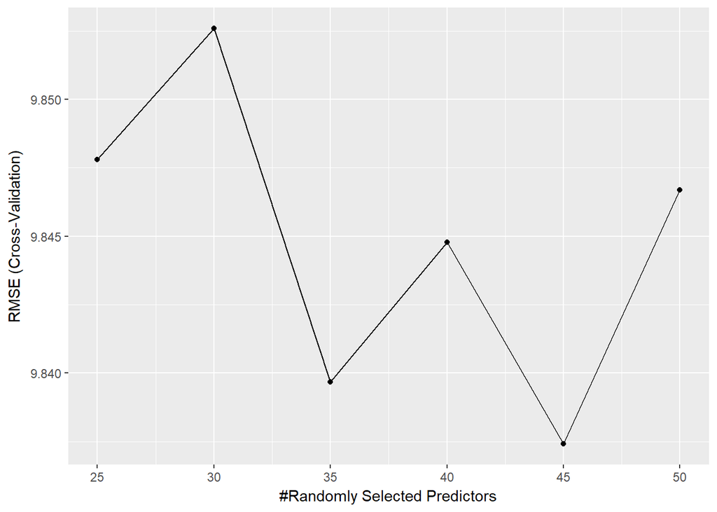

```r
ggplot(rf_fit)
```

## GBM

Now let us train a gbm using the `gbm` package.

Parameters to tune are `n.trees`, `interaction.depth`, `shrinkage`, and `n.minobsinnode`.

`shrinkage` and `n.minobinnode` are fixed at reasonable values, while we tune `n.trees` and `interaction.depth`.

```r
gbm_grid <- expand.grid(
    n.trees = 1:4 * 100,
    interaction.depth = 3:9 * 2,
    shrinkage = 0.05,
    n.minobsinnode = 10
  )
```

Now train tune the gbm using `train`.

```r
gbm_fit <- train(X_train, y_train,
                trControl = fitControl,
                tuneGrid = gbm_grid,
                preProcess = c("center", "scale"),
                method = "gbm",
                distribution = "gaussian")
```

```r
gbm_fit
```

```
## Stochastic Gradient Boosting
##
## 5000 samples
##   90 predictor
##
## Pre-processing: centered (90), scaled (90)
## Resampling: Cross-Validated (5 fold)
## Summary of sample sizes: 4000, 4000, 4000, 4000, 4000
## Resampling results across tuning parameters:
##
##   interaction.depth  n.trees  RMSE      Rsquared   MAE
##    6                 100      9.800493  0.2165748  7.010822
##    6                 200      9.684760  0.2314851  6.871862
##    6                 300      9.673820  0.2340246  6.854660
##    6                 400      9.664127  0.2369961  6.856405
##    8                 100      9.741686  0.2242310  6.958827
##    8                 200      9.670220  0.2338606  6.865572
##    8                 300      9.636119  0.2404584  6.822957
##    8                 400      9.657727  0.2386255  6.843051
##   10                 100      9.737641  0.2236727  6.943966
##   10                 200      9.671346  0.2343531  6.851830
##   10                 300      9.706758  0.2313745  6.871208
##   10                 400      9.718573  0.2309774  6.868235
##   12                 100      9.746294  0.2221545  6.937715
##   12                 200      9.666273  0.2356254  6.838676
##   12                 300      9.690910  0.2339446  6.850431
##   12                 400      9.694076  0.2346411  6.845310
##   14                 100      9.733699  0.2235955  6.921238
##   14                 200      9.703229  0.2304253  6.877172
##   14                 300      9.708861  0.2316015  6.888182
##   14                 400      9.747556  0.2274547  6.923795
##   16                 100      9.711368  0.2267301  6.878182
##   16                 200      9.683584  0.2337445  6.817891
##   16                 300      9.709763  0.2319590  6.831737
##   16                 400      9.747587  0.2280187  6.870364
##   18                 100      9.684681  0.2313346  6.855770
##   18                 200      9.646654  0.2391567  6.807694
##   18                 300      9.667743  0.2378127  6.823561
##   18                 400      9.701434  0.2343979  6.852185
##
## Tuning parameter 'shrinkage' was held constant at a value of 0.05
##
## Tuning parameter 'n.minobsinnode' was held constant at a value of 10
## RMSE was used to select the optimal model using the smallest value.
## The final values used for the model were n.trees = 300,
##  interaction.depth = 8, shrinkage = 0.05 and n.minobsinnode = 10.
```

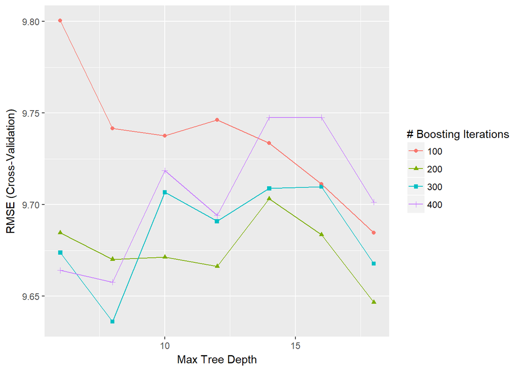

```r
ggplot(gbm_fit)
```

## Model comparison

```r
y_rf <- predict(rf_fit, X_test)
```

```
## Predicting.. Progress: 50%. Estimated remaining time: 30 seconds.
## Predicting.. Progress: 99%. Estimated remaining time: 0 seconds.
```

```r
y_gbm <- predict(gbm_fit, X_test)
y_lm <- predict(lm_fit, X_test)
y_lasso <- predict(lasso_fit, X_test)

list(y_lm, y_lasso, y_rf, y_gbm) %>%
  map(~ postResample(., y_test)) %>%
  map(as.list) %>%
  bind_rows() %>%
  mutate(model = c("Linear Regression", "Lasso", "RF", "GBM")) %>%
  select(model, RMSE:MAE) %>%
  kable()
```

| model | RMSE | Rsquared | MAE |
| --- | --- | --- | --- |
| Linear Regression | 9.663580 | 0.2198742 | 6.970184 |
| Lasso | 9.642409 | 0.2219944 | 6.942516 |
| RF | 9.713645 | 0.2176223 | 7.133038 |
| GBM | 9.439356 | 0.2558420 | 6.705474 |

## Adaptive Resampling

Another potentially useful tuning method is adaptive resampling.

Tuning is generally an iterative process. Cast a wide net at the beginning and use those results to guide where to focus.

`caret` attempts to do the iterative process for you with adaptive resampling.

When specifying `method = "adaptive_cv"`, `caret` will use information from the past parameter results to choose what parameters to try next.

```r
adaptiveFitControl <- trainControl(method = "adaptive_cv",
                                   search = "random",
                                   adaptive = list(min = 4, alpha = .05,
                                                   methods = "gls",
                                                   complete = TRUE),
                                   number = 5,
                                   allowParallel = TRUE)
```

I hate tuning gbms, so let’s see how close `caret` gets to the manual grid specification.

```r
adaptive_gbm_fit <- train(X_train, y_train,
                trControl = adaptiveFitControl,
                preProcess = c("center", "scale"),
                method = "gbm",
                distribution = "gaussian",
                tuneLength = 10)
adaptive_gbm_fit
```

```
## Stochastic Gradient Boosting
##
## 5000 samples
##   90 predictor
##
## Pre-processing: centered (90), scaled (90)
## Resampling: Adaptively Cross-Validated (5 fold, repeated 1 times)
## Summary of sample sizes: 4000, 3999, 4000, 4001, 4000
## Resampling results across tuning parameters:
##
##   shrinkage    interaction.depth  n.minobsinnode  n.trees  RMSE
##   0.007648424   1                  6              2237     10.200153
##   0.010862302   5                 25              4580      9.623981
##   0.054148621   7                 17              3597     10.286806
##   0.121863861   1                 15              1818     10.381542
##   0.128848763   8                 15              2451     10.736659
##   0.254174951   5                 23               397     10.982367
##   0.446751425  10                 25               766     12.740990
##   0.496744055   7                 15              4926     12.875277
##   0.519793415  10                  7              3705     13.789123
##   0.585780372   8                 25               729     14.016418
##   Rsquared    MAE        Resamples
##   0.20900358   7.206885  2
##   0.24554985   6.782834  5
##   0.20509602   7.187198  2
##   0.18884494   7.361803  2
##   0.16591787   7.559688  2
##   0.16022987   7.871653  2
##   0.09329267   9.486611  2
##   0.09341917   9.493619  2
##   0.07175027  10.257038  2
##   0.08053651  10.600890  2
##
## RMSE was used to select the optimal model using the smallest value.
## The final values used for the model were n.trees = 4580,
##  interaction.depth = 5, shrinkage = 0.0108623 and n.minobsinnode = 25.
```

```r
adaptive_gbm_fit$results %>%
  arrange(RMSE) %>%
  head() %>%
  kable()
```

| shrinkage | interaction.depth | n.minobsinnode | n.trees | RMSE | Rsquared | MAE | RMSESD | RsquaredSD | MAESD | .B |
| --- | --- | --- | --- | --- | --- | --- | --- | --- | --- | --- |
| 0.0108623 | 5 | 25 | 4580 | 9.623981 | 0.2455499 | 6.782834 | 0.3620811 | 0.0172659 | 0.2008621 | 5 |
| 0.0076484 | 1 | 6 | 2237 | 10.200153 | 0.2090036 | 7.206886 | 0.2761846 | 0.0234349 | 0.0964623 | 2 |
| 0.0541486 | 7 | 17 | 3597 | 10.286806 | 0.2050960 | 7.187198 | 0.1452954 | 0.0002553 | 0.1970877 | 2 |
| 0.1218639 | 1 | 15 | 1818 | 10.381542 | 0.1888449 | 7.361803 | 0.1755867 | 0.0032968 | 0.1860498 | 2 |
| 0.1288488 | 8 | 15 | 2451 | 10.736659 | 0.1659179 | 7.559687 | 0.3910703 | 0.0226781 | 0.2811213 | 2 |
| 0.2541750 | 5 | 23 | 397 | 10.982367 | 0.1602299 | 7.871653 | 0.0519834 | 0.0299592 | 0.0655619 | 2 |